# Git, GitHub & Ocean Acidification

YouzhiHuang(u7457916)

2022-09-09

# **Introduction**

This tutorial will draw on the skills you have already learnt on data visualisation, data wrangling and NHST to analyse a data set on ocean acidification effects on fish behaviour. However, we’ll do that in the context of some new workflows that adopt Git and GitHub.

Use this Rmarkdown file as your template to complete the tasks outlined within the instructions. There are questions asked in the instructions and here in the RMarkdown file. Answer these as best as you can to document your steps and thinking. There are also a series of coding exercises.

Throughout we are also going to learn a bit more about how to format Rmarkdown documents. So, pay close attention to the formatting. We’re also going to make use of the `bookdown` package now to render your Rmarkdown because, well, it’s quite elegant in many ways. Before you start the tasks install the following packages:

```r
# Install a load of packages that we'll use. I'll show you a shortcut that I love to use. Try using the p_load function in the "pacman" package. p_load will execute both the install.packages and library commands in one shot so they only need to be used once to install pacman itself.
# install.packages("pacman", repos = "http://cran.us.r-project.org")
library(pacman)
# Install bookdown for rendering because we'll need this. While we're at it, lets also install /load the tidyverse
p_load(bookdown, tidyverse, ggforce, flextable, latex2exp, png, magick) # basically just list all the packages you want here
```

# **Task 1**

### Provide the link to your GitHub Repo

While the tasks are meant to get you familiar with how *GitHub* works you should try and make regular commits as you work your way through. We want to see how often you’re using *Git*. Below, within the `()` brackets provide the link to your GitHub Repo. Just cut and paste it so we know what the repo name is and where it is.

[My GitHub Repository](https://github.com/YouzhiHuang/Version-Control-Git-and-GitHub/commits/main)

By adding the link in the `()` brackets it will hyperlink “My GitHub Repository”. This is how to hyperlink in Rmarkdown documents.

# **Task 2**

This task involves cloning your repository on your computer. Where should we place this repository? While GitHub is somewhat of a cloud storage system because it’s keeping record of your commits, files and changes in the cloud it is **not** a backup of your files (note that placing `**` around a word will bold it whereas `*` around a word will italicise it). The lack of *GitHub* being a file backup system is important to recognise!

> **Question 1**: Why should you not rely on *GitHub* as a backup?

```r
## Write your answer here.
This is an online platform and, depending on the network, it is not always accessible. For example in China it is not accessible.
```

I’d usually suggest placing your repo in a cloud storage system like, *OneDrive*, *Dropbox*, or *GoogleDrive*. These will ensure that all your files are backed up and *GitHub* will provide a record of the detailed history.

Before moving on you might have noticed that the code block above has a name `answer1` and I’ve added an argument `echo = TRUE`. It’s good to label code blocks with useful names to help you debug when rendering of your document goes wrong (when, not IF!). These names need to all be unique. There are a whole bunch of arguments that you can list within code chunks that tell each chunk what to do. You can look to the great [Rmarkdown cheetsheet](https://www.rstudio.com/wp-content/uploads/2015/02/rmarkdown-cheatsheet.pdf) for more information.

> **Question 2**: In the second code block called `answer1` if we change echo = TRUE to echo = FALSE what will happen to the code block `answer1` when you render it?

**Important**: Notice that `eval = FALSE` for many code chunks. When you complete the tasks. Make sure to change these to `TRUE` otherwise you will find your code does not run!

# **Task 3**

Hopefully you have now successfully cloned down your *GitHub* repo. This is your new working directory from which your project will develop.

Hopefully you also created and/or downloaded the following files and added them to your cloned repo:

1. created a new RStudio project file in your working directory
2. download the `OA_activitydat_20190302_BIOL3207.csv` from Wattle and add this to a `data/` folder in your repo
3. Add the template Rmarkdown file, `git_fishes_student.Rmd` that was provided on wattle. You’ll use this file to work through the tasks and answer questions.

**STOP**: Before moving on, it’s a good time to establish some good *GitHub* practices. You have just did an important step – you added a bunch of new files. It’s time stage these files and commit them so that you have a record. Use *GitHub Desktop* to do this.

This is also a very good point to make sure that you understand relative path names fo coding. Wait, “relative what?”. Your working directory can be considered the ‘lowest’ level of your project. The starting point, if you will. R needs to know where your files are that you want to load. Many people might be familiar with using the `setwd()` function to tell R where your files are that you need to load. This is problematic because everyone’s path to a given working directory is different, and so, your code will not work on others’ computers. Even across your own computers!

Lucky, RStudio project files take away the main issue by creating a project file that allows anyone to click on it to open the working directory to the same “spot”. Having said that, if you start building structure (i.e., folders) in your working directory or repo than you need to understand how to navigate between folders to load and write files in the places that you want.

Make sure you have added a `data/` folder to your working directory that you just cloned down. Think about how you would write some code to load in a data file that is within this folder. There are a few useful shortcuts you can use. For example, if you use `.` it means ‘start from the current working directory’. That is the RStudio project file location if you click on a RStudio project. If you use `..` it means “start from the directory or folder one step back from the existing working directory”.

> **Question 3**: **How would you write the path name to load in a data file from the data folder?**

Write your answer in the code chunk below:

```r
path <- "./data/OA_activitydat_20190302_BIOL3207.csv"
library(tidyverse)
data <- read_csv(path)
data
```

Let’s say that you added a new data folder that was inside an output folder (i.e., `output/data`) to your working directory. The purpose of this folder is to store and track your cleaned up data frame after you have done all your data wrangling and corrections.

> **Question 4**: Using the `write_csv` function how would you write the path name to save this file to `output/data`?

```r
path1 <- "./output/data/dt"

write_csv(dt, file = path1)
```

# **Task 4**

We’re ready for some coding! Lets do some coding and wrangling of the `OA_activitydat_20190302_BIOL3207.csv` data that we will use for the workshop. Note above, the `loaddata` code chunk should have already written the code to load the data file. At this point, we’re assuming it’s in your working space. If not, make sure you run the `loaddata` code chunk.

First, write some code below to remove missing data

```r
## Code to removing missing data from the `OA_activitydat_20190302_BIOL3207.csv` data frame.
library(tidyverse)
path <- "./data/OA_activitydat_20190302_BIOL3207.csv"
data <- read_csv(path)
```

```
## -------------------------------------------------------- Delimiter: "," chr
## (5): loc, species, treatment, size, comment dbl (4): ...1, animal_id, sl,
## activity
```

```r
comp_data <-  data %>% select(-...1)%>% drop_na()
comp_data
```

```
## # A tibble: 550 x 8
##    loc       species treatment animal_id    sl size  activity comment
##    <chr>     <chr>   <chr>         <dbl> <dbl> <chr>    <dbl> <chr>
##  1 LIRS 2014 ambon   CO2              64  57.0 big       8.15 27min means of sm~
##  2 LIRS 2014 ambon   CO2              65  38.2 big      10.5  27min means of sm~
##  3 LIRS 2014 ambon   CO2              67  39.3 big       6.51 27min means of sm~
##  4 LIRS 2014 ambon   CO2              68  36.1 big      27.8  27min means of sm~
##  5 LIRS 2014 lemon   CO2              74  36.4 big      36.7  27min means of sm~
##  6 LIRS 2014 ambon   CO2              75  35.9 big      42.8  27min means of sm~
##  7 LIRS 2014 lemon   CO2              81  35.7 big      21.9  27min means of sm~
##  8 LIRS 2014 ambon   CO2              84  38.4 big      24.6  27min means of sm~
##  9 LIRS 2014 ambon   CO2              85  48.3 big      35.1  27min means of sm~
## 10 LIRS 2014 ambon   CO2              88  43.4 big       1.02 27min means of sm~
## # ... with 540 more rows
```

Second, drop out irrelevant columns and check that there are no spelling issues in `species` and `treatment`. Create a table of summary data that includes: 1) the mean, 2) the standard error and 3) the sample sizes of unique fish across ALL six fish species for each treatment. This will also help you detect any spelling errors. You can use the R package [`flextable`](https://ardata-fr.github.io/flextable-book/) to print out the results in a nice neat format! If you haven’t heard about `flextable` spend 10 or so minutes having a look at it’s functionality. It’s incredible! You’ll use this for tables throughout.

```r
# Drop irrelevant columns
Sp_Tr <- comp_data %>% select(-c(comment,loc,animal_id,size))
Sp_Tr
```

```
## # A tibble: 550 x 4
##    species treatment    sl activity
##    <chr>   <chr>     <dbl>    <dbl>
##  1 ambon   CO2        57.0     8.15
##  2 ambon   CO2        38.2    10.5
##  3 ambon   CO2        39.3     6.51
##  4 ambon   CO2        36.1    27.8
##  5 lemon   CO2        36.4    36.7
##  6 ambon   CO2        35.9    42.8
##  7 lemon   CO2        35.7    21.9
##  8 ambon   CO2        38.4    24.6
##  9 ambon   CO2        48.3    35.1
## 10 ambon   CO2        43.4     1.02
## # ... with 540 more rows
```

```r
# Check spelling in species and treatment but also generate a summary table
unique(Sp_Tr$species)
```

```
## [1] "ambon"     "lemon"     "chromis"   "acantho"   "humbug"    "whitedams"
```

```r
unique(Sp_Tr$treatment)
```

```
## [1] "CO2"     "control"
```

```r
summary(Sp_Tr)
```

```
##    species           treatment               sl        activity
##  Length:550         Length:550         Min.   : 8   Min.   : 1
##  Class :character   Class :character   1st Qu.:11   1st Qu.:19
##  Mode  :character   Mode  :character   Median :22   Median :28
##                                        Mean   :24   Mean   :28
##                                        3rd Qu.:33   3rd Qu.:37
##                                        Max.   :93   Max.   :58
```

```r
# Use flextable to render the summary table in a tidy format
use_df_printer()
set_flextable_defaults(
  theme_fun = theme_booktabs,
  big.mark = " ",
  font.color = "#666666",
  border.color = "#666666",
  padding = 3,
)
# Create a summary of the original dataset.
dat <- Sp_Tr |>
  group_by(treatment,species) |>
  summarise(n=n(),
    across(
      where(is.numeric),
      .fns = list(
        avg = ~ mean(.x, na.rm = TRUE),
        se = ~ sd(.x, na.rm = TRUE)/sqrt(n)
      )
    ),.groups = "drop" ) |>  subset(select=-c(n_avg,n_se))
dat
```

| treatment character | species character | n integer | sl_avg numeric | sl_se numeric | activity_avg numeric | activity_se numeric |
| --- | --- | --- | --- | --- | --- | --- |
| CO2 | acantho | 86 | 18.4 | 1.9 | 27.3 | 1.1 |
| CO2 | ambon | 22 | 37.5 | 1.5 | 18.4 | 2.6 |
| CO2 | chromis | 14 | 32.0 | 3.2 | 24.8 | 2.9 |
| CO2 | humbug | 62 | 31.7 | 1.5 | 40.3 | 1.5 |
| CO2 | lemon | 19 | 28.8 | 0.9 | 26.0 | 2.5 |
| CO2 | whitedams | 60 | 14.5 | 1.0 | 24.5 | 1.3 |
| control | acantho | 90 | 19.6 | 1.9 | 28.9 | 1.2 |
| control | ambon | 21 | 38.5 | 1.7 | 17.3 | 2.5 |
| control | chromis | 20 | 33.4 | 1.9 | 26.1 | 2.0 |
| control | humbug | 65 | 31.8 | 1.4 | 34.9 | 1.7 |

n: 12

```r
fdata <-  as_tibble(dat)
# Use flextable to render the summary table
ft <-  fdata|>
  flextable() |>
  separate_header() |>
  autofit() |>
  theme_booktabs(bold_header = TRUE) |>
  footnote(i = 1, j=4,
           part = "header",
           ref_symbols = " ",
           value = as_paragraph("sl: Standard length of the fish in mm")) |>
  footnote(i = 2, j = grep("avg", colnames(fdata), value = TRUE),
           part = "header",
           ref_symbols = " ",
            value = as_paragraph("avg: Arithmetic Mean")) |>
  footnote(i = 2, j = grep("se", colnames(fdata), value = TRUE),
           part = "header",
           ref_symbols = " ", value = as_paragraph("se: Standard Error")) |>
  align(align = "center", part = "all", j = 4:7) |>
  merge_v(j = 1) |>
  valign(j = 1, valign = "top") |>
  colformat_double(digits = 2)
ft
```

| treatment | species | n | sl avg | sl se | activity avg | activity se |
| --- | --- | --- | --- | --- | --- | --- |
| CO2 | acantho | 86 | 18.39 | 1.88 | 27.30 | 1.12 |
|  | ambon | 22 | 37.47 | 1.48 | 18.39 | 2.60 |
|  | chromis | 14 | 31.95 | 3.19 | 24.78 | 2.93 |
|  | humbug | 62 | 31.69 | 1.46 | 40.28 | 1.51 |
|  | lemon | 19 | 28.82 | 0.89 | 26.04 | 2.51 |
|  | whitedams | 60 | 14.47 | 0.98 | 24.46 | 1.28 |
| control | acantho | 90 | 19.62 | 1.90 | 28.93 | 1.19 |
|  | ambon | 21 | 38.50 | 1.68 | 17.34 | 2.50 |
|  | chromis | 20 | 33.43 | 1.88 | 26.10 | 2.04 |
|  | humbug | 65 | 31.77 | 1.36 | 34.92 | 1.72 |
|  | lemon | 30 | 28.85 | 0.87 | 19.80 | 2.24 |
|  | whitedams | 61 | 13.97 | 0.99 | 26.59 | 1.40 |

sl: Standard length of the fish in mm  
avg: Arithmetic Mean  
se: Standard Error

**STOP**: Before moving on, it’s a good time to establish some good *GitHub* practices. You have just done an important step. It’s time to save this file, stage it and commit it so that you have a record. Push these changes up using *GitHub Desktop*. It’s important to do this frequently. It’s probably not needed after every line of code, but it’s good to do this when you have completed an important coding step. Of course, there’s no harm in doing it more often. It will provide fine-scale tracking for you!

> **Question 5**: The new version of your Rmarkdown file should now be up on *GitHub*. In the browser window click on your most recent commit. Have a look at the file versioning system. You will notice two files side-by-side. Describe what you notice is being presented online. What do the red and green highlights mean?

```r
## The red and green highlights in the online presentation are the deleted and added lines of code respectively
```

# **Task 5**

Ignoring figures can be important because they take up quite a lot of space in your *GitHub* repo. For example, huge data files, or figures (e.g., png) can take up a tonne of space. We also might not need to save and track these because we can recreate them with our own code or re-download, process, save and track what we need.

`.gitignore` files are used to control what *Git* tracks and what it ignores. You should have created a new folder path: `output/figures/`. Write some code now to create a pretty figure using ggplot that shows the difference between control and acidification treatments for each of the fish species in the data set:

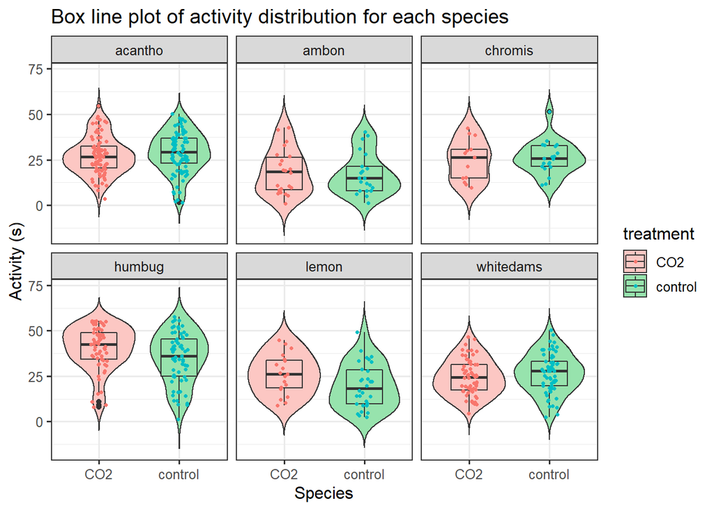

```r
# ggplot figure showing mean activity for each treatment (Control, OA) for each species.
fig1 <- comp_data %>% ggplot(aes(x = treatment, y = activity, fill = treatment)) +
  geom_violin(trim = F) +
  facet_wrap(~species)+
  geom_boxplot(width = 0.45)+
  geom_jitter(aes(colour = treatment),size = 0.9,width=0.1,height=0)+
  theme_bw(base_size = 14)+ theme_bw(base_size = 12)+
  xlab('Species') + ylab('Activity (s)')+
  ggtitle("Box line plot of activity distribution for each species")+
  scale_fill_manual(values = c("#FCC7C3","#97E3AD","#BED7FF"))
fig1
```

**Stretch Task**: The Clark et al. 2020 paper plots some pretty pictures on their figures. You have access to a folder called “pics/”. Add the pics of the difference species from the “pics/” folder to your new plot. Explore the function `annotation_raster()` which might help you achieve this goal.

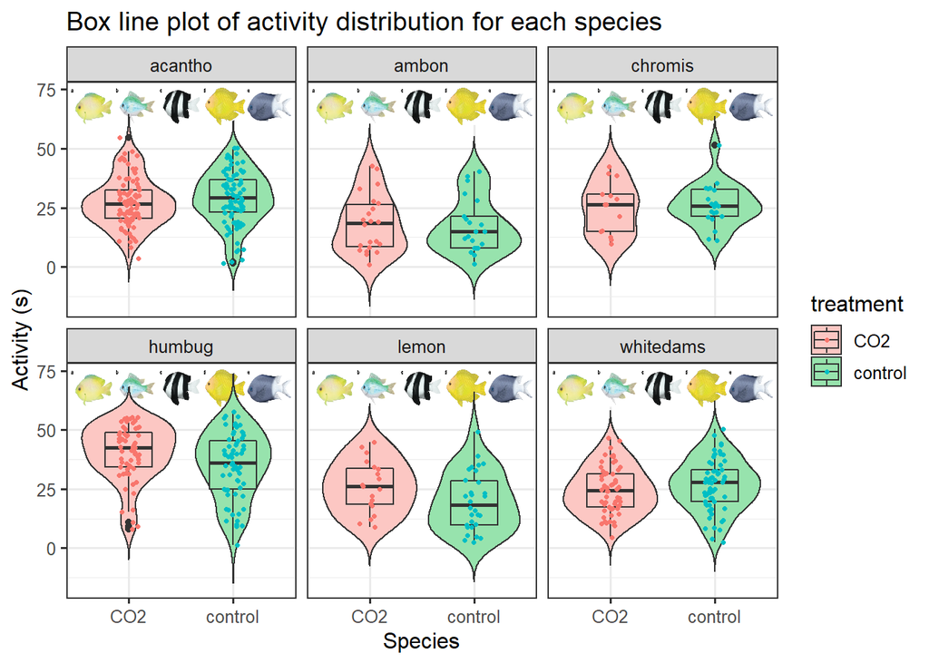

```r
pathf <- "./data/pics/20220908160026.png"
fig <- readPNG(pathf)
figs <- comp_data %>% ggplot(aes(x = treatment, y = activity, fill = treatment)) +
  annotation_raster(fig,-Inf, Inf, 60, Inf)+
  geom_violin(trim = F) +
  facet_wrap(~species)+
  geom_boxplot(width = 0.45)+
  geom_jitter(aes(colour = treatment),size = 0.9,width=0.1,height=0)+
  theme_bw(base_size = 14)+ theme_bw(base_size = 12)+
  xlab('Species') + ylab('Activity (s)')+
  ggtitle("Box line plot of activity distribution for each species")+
  scale_fill_manual(values = c("#FCC7C3","#97E3AD","#BED7FF"))
figs
```

Note the code chunk used to make the figure. It has a `fig.cap` argument. That means Rmarkdown knows it’s a figure and it will allow you to create a figure reference call. In other words, we can refer to our Figure 1 by referring to the label for the chunk. This will automatically make a legend for us too (assuming you add one in). The same concept applied to Tables but the legend goes above these.

Now that you have the figure you may also want to write / save it as a separate file. Use `ggsave` function to save the figure(s) to your new `output/figures/`:

```r
# Use ggsave to save the figure
ggsave("./output/figures/figs.png",figs)
```

> **Question 6**: Given that you have added `output/figures/` to your `.gitignore` file describe what you notice about what you see in *GitHub Desktop*.

```r
## Write your answer here
# I will not see any changes under the specified path in *GitHub Desktop*, so they will not be uploaded to GitHub either.
```

Last question for this task. I promise! It’s important to think very carefully about what you track and ignore.

> **Question 7**: Assume that you added the `pics/` folder to your working directory to plot pictures of each fish on your figure. Do you want to track the files in the pic/ folder on GitHub despite them being .png files? Explain your reasoning.

```r
## Add your answer here
# When I added the `pics/` folder to my working directory, I drew a picture of each fish on the fig. I didn't want to keep track of the files in the pic/ folder on GitHub, even though they are .png files. Because it is not important that these pictures change, everyone can choose which pictures of each fish they like. A record of the changes to these pictures is not necessary. It would instead take up a lot of space.
```